# 1.Amazon Reviews case Study (1)

```python
import pandas as pd
import numpy as np
import matplotlib.pyplot as plt
```

```python
#!pip install nltk
```

```python
#!pip install wordcloud
```

```python
import nltk
```

```python
#nltk.download()
```

```python
reviews = pd.read_csv(r"C:\Users\Administrator\Desktop\unstructured elective\dataset\K8 Reviews v0.2.csv")
```

```python
reviews.head()
```

|  | sentiment | review |
| --- | --- | --- |
| 0 | 1 | Good but need updates and improvements |
| 1 | 0 | Worst mobile i have bought ever, Battery is dr... |
| 2 | 1 | when I will get my 10% cash back.... its alrea... |
| 3 | 1 | Good |
| 4 | 0 | The worst phone everThey have changed the last... |

```python
#Dataset if scrapped from Amazon for Lenovo K8 mobile phones
# Review in the form of free text was scrapped and the user rating
# A user rating of 1,2,3 -> sentiment 0
# A user rating of 4 and 5 -> sentiment 1
```

```python
reviews.shape
```

```
(14675, 2)
```

```python
reviews.sentiment.value_counts()
```

```
0    7712
1    6963
Name: sentiment, dtype: int64
```

### Get the word cloud:

```
1. combine all the reviews into a single string
2. instantiate word cloud
3. generate the word cloud
```

```python
from wordcloud import WordCloud
```

```python
reviews_combined = " ".join(reviews.review.values)
```

```python
lst = ["A","B","C"]
" ".join(lst)
```

```
'A B C'
```

```python
len(reviews_combined)
```

```
1674772
```

```python
reviews_combined[:200]
```

```
'Good but need updates and improvements Worst mobile i have bought ever, Battery is draining like hell, backup is only 6 to 7 hours with internet uses, even if I put mobile idle its getting discharged.'
```

```python
word_cloud = WordCloud().generate(reviews_combined)
```

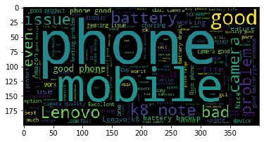

```python
plt.figure()
plt.imshow(word_cloud)
plt.show()
```

```python
word_cloud = WordCloud(width=800,height=800,
                       background_color='white',
                       max_words=150).\
generate(reviews_combined)
```

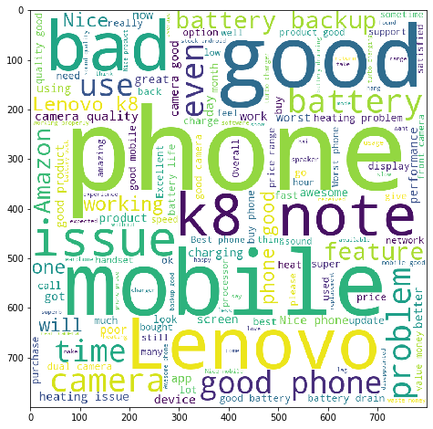

```python
plt.figure(figsize=[8,8])
plt.imshow(word_cloud)
plt.show()
```

## Bar graph of top 25 used words

1. get the words and the frequencies
2. sort based on frequencies and get the top 25 words
3. plot the bar graph

```python
#Preparing a dictionary of words and their frequencies
all_terms = []
fdist = {}
all_terms = reviews_combined.split(" ")
for word in all_terms:
    fdist[word] = fdist.get(word,0) + 1
```

```python
#From the dict obtain a data frame of words and freq's
freq = {"words":list(fdist.keys()),"freq":list(fdist.values())}
df_dist = pd.DataFrame(freq)
```

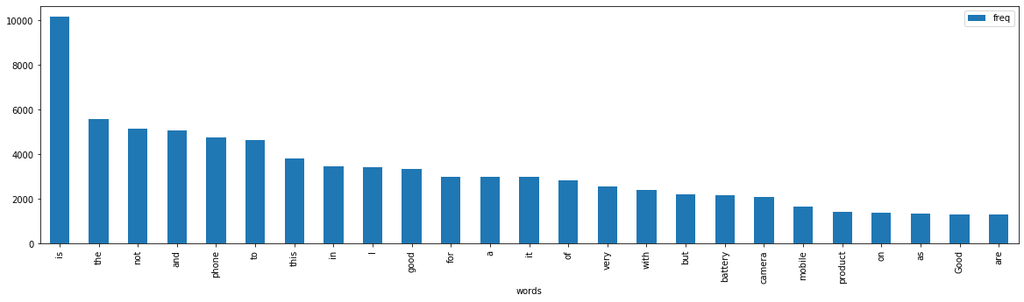

```python
%matplotlib inline
df_dist.sort_values(ascending=False, by="freq").head(25).\
plot.bar(x= "words", y= "freq",figsize=(20,5))
```

Problems with these visuals: 1.Too many distinct words in the corpus of reviews 1.text is non unifrom case 2.punctuations present in the text

```
    3. there are language connectors in the text - stop words
    4. Words with different forms/tenses - charge, charged, charging
```

Basic Text processing tasks:

```
1. Text cleaning
2. Get the visuals - word cloud and bar graph or frequency graph
3. Converting text to numeric matrices
4. Advanced visuals using collocations(n-grams - unigrams, bigrams, trigrams)
5. Sentiment analysis and sentiment classification
6. text classification
7. document clustering
```

```python
from nltk.tokenize import word_tokenize
```

```python
all_terms = word_tokenize(reviews_combined.lower())
```

```python
print(all_terms[:20])
```

```
['good', 'but', 'need', 'updates', 'and', 'improvements', 'worst', 'mobile', 'i', 'have', 'bought', 'ever', ',', 'battery', 'is', 'draining', 'like', 'hell', ',', 'backup']
```

```python
len(reviews_combined), len(all_terms)
```

```
(1674772, 324233)
```

```python
from nltk.probability import FreqDist
```

```python
fdist = FreqDist(all_terms)
fdist
```

```
FreqDist({'.': 13530, 'is': 10386, ',': 6890, 'phone': 6565, 'the': 6526, 'not': 6030, 'good': 5717, 'and': 5413, 'it': 5375, 'to': 4697, ...})
```

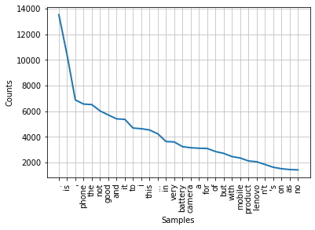

```python
fdist.plot(30,cumulative=False)
plt.show()
```

```python
#fdist.plot
```

The head and the tail of the above graph consists of either punct or stop words which needs to be removed

```python
from string import punctuation
from nltk.corpus import stopwords
```

```python
stop_nltk = stopwords.words("english")
```

```python
stop_updated = stop_nltk + ["...",".."] +\
["mobile","phone","lenovo","k8","note","n't",'100']
```

```python
reviews_updated1 = [term for term in all_terms \
if term not in stop_updated and term
                    not in list(punctuation) and len(term)>2]
```

```python
len(set(reviews_updated1))
```

```
18475
```

```python
print(reviews_updated1[:200])
```

```
['good', 'need', 'updates', 'improvements', 'worst', 'bought', 'ever', 'battery', 'draining', 'like', 'hell', 'backup', 'hours', 'internet', 'uses', 'even', 'put', 'idle', 'getting', 'discharged.this', 'biggest', 'lie', 'amazon', 'lenove', 'expected', 'making', 'full', 'saying', 'battery', '4000mah'…
```

```python
from nltk.stem import SnowballStemmer
stemmer_s = SnowballStemmer("english")
```

```python
reviews_updated_stem = [ stemmer_s.stem(word) for word in reviews_updated1]
```

```python
from nltk.stem import WordNetLemmatizer
lemm = WordNetLemmatizer()
```

```python
reviews_updated_lemm = [ lemm.lemmatize(word) for word in reviews_updated1]
```

```python
print(len(set(reviews_updated_stem)),len(set(reviews_updated_lemm)))
```

```
16161 17902
```

stemmer reduces the number of distinct words in the corpus to a greater exten

lets build a udf

- input : review
- Tasks : All the above cleaning steps
- Return : string of cleaned reveiw

based on the outcome of this function, you should be able to add a new column in the data frame called as "cleaned_review"

```python
def clean_txt(sent):
    tokens = word_tokenize(sent.lower())
    lemmed = [lemm.lemmatize(term) for term in tokens \
               if term not in stop_updated and \
                term not in list(punctuation) and\
               len(term) > 2]
    res = " ".join(lemmed)
    return res
```

```python
reviews['clean_review'] = reviews.review.apply(clean_txt)
```

```python
reviews.head()
```

[output not shown]

# Word cloud on cleaned dataset

```python
reviews_combined = " ".join(reviews.clean_review.values)
```

```python
reviews_combined[:500]
```

```
'good need update improvement worst bought ever battery draining like hell backup hour internet us even put idle getting discharged.this biggest lie amazon lenove expected making full saying battery 4000mah booster charger fake take least hour fully charged.do know survive making full us.please else…
```

```python
word_cloud = WordCloud(width=800,height=800,background_color='white',max_words=150).\
generate_from_text(reviews_combined)
```

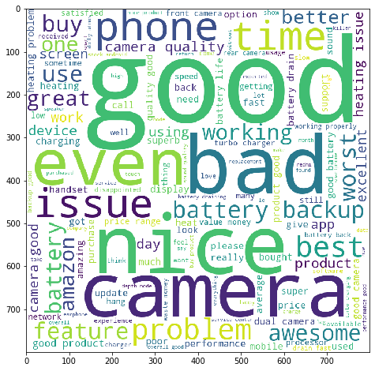

```python
plt.figure(figsize=[8,8])
plt.imshow(word_cloud)
plt.show()
```

# Bar Graph on top 25 words

```python
all_terms = []
fdist = {}
all_terms = reviews_combined.split(" ")
for word in all_terms:
    fdist[word] = fdist.get(word,0) + 1
```

```python
freq = {"words":list(fdist.keys()),"freq":list(fdist.values())}
df_dist = pd.DataFrame(freq)
```

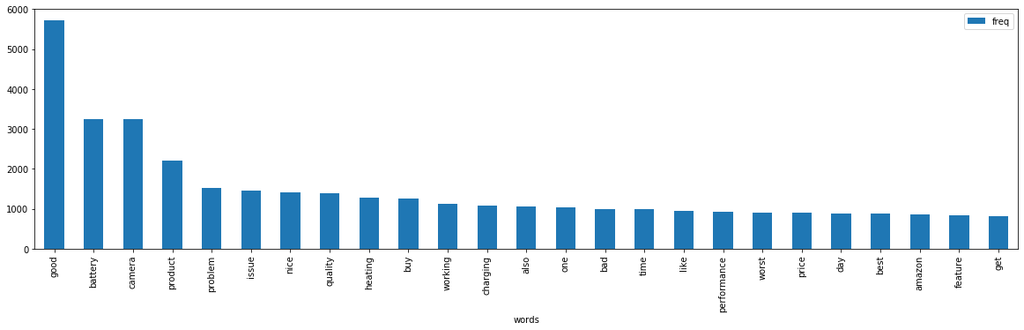

```python
%matplotlib inline
df_dist.sort_values(ascending=False, by="freq").head(25).\
plot.bar(x= "words", y= "freq",figsize=(20,5))
```

# Plot the bar graph for top 25 frequenctly used bigrams

```python
from sklearn.feature_extraction.text import CountVectorizer
```

```python
# create a bigram count vectorizer object
bigram_count_vectorizer = CountVectorizer(ngram_range=(2,2),max_features=150)
```

```python
X_bigram = bigram_count_vectorizer.fit_transform(reviews['clean_review'])

# Creating a DTM
DTM_bigram = pd.DataFrame(X_bigram.toarray(), columns=bigram_count_vectorizer.get_feature_names())
```

```python
DTM_bigram
```

|  | 4000 mah | 4000mah battery | 4gb ram | also good | back camera | back cover | backup good | bad camera | bad experience | bad product | battery back | battery backup | battery charging | battery drain | battery draining | battery good | battery issue | battery last | battery life | battery performance | battery problem | best price | bokeh effect | build quality | buy product | call recorder | call recording | camera also | camera average | … |
| --- | --- | --- | --- | --- | --- | --- | --- | --- | --- | --- | --- | --- | --- | --- | --- | --- | --- | --- | --- | --- | --- | --- | --- | --- | --- | --- | --- | --- | --- | --- |
| 0 | 0 | 0 | 0 | 0 | 0 | 0 | 0 | 0 | 0 | 0 | 0 | 0 | 0 | 0 | 0 | 0 | 0 | 0 | 0 | 0 | 0 | 0 | 0 | 0 | 0 | 0 | 0 | 0 | 0 | … |
| 1 | 0 | 0 | 0 | 0 | 0 | 0 | 0 | 0 | 0 | 0 | 0 | 0 | 0 | 0 | 1 | 0 | 0 | 0 | 0 | 0 | 0 | 0 | 0 | 0 | 0 | 0 | 0 | 0 | 0 | … |
| 2 | 0 | 0 | 0 | 0 | 0 | 0 | 0 | 0 | 0 | 0 | 0 | 0 | 0 | 0 | 0 | 0 | 0 | 0 | 0 | 0 | 0 | 0 | 0 | 0 | 0 | 0 | 0 | 0 | 0 | … |
| 3 | 0 | 0 | 0 | 0 | 0 | 0 | 0 | 0 | 0 | 0 | 0 | 0 | 0 | 0 | 0 | 0 | 0 | 0 | 0 | 0 | 0 | 0 | 0 | 0 | 0 | 0 | 0 | 0 | 0 | … |
| 4 | 0 | 0 | 0 | 0 | 0 | 0 | 0 | 0 | 0 | 0 | 0 | 0 | 0 | 0 | 0 | 0 | 0 | 0 | 0 | 0 | 0 | 0 | 0 | 0 | 0 | 0 | 0 | 0 | 0 | … |
| ... | ... | ... | ... | ... | ... | ... | ... | ... | ... | ... | ... | ... | ... | ... | ... | ... | ... | ... | ... | ... | ... | ... | ... | ... | ... | ... | ... | ... | ... | … |
| 14670 | 0 | 0 | 0 | 0 | 0 | 0 | 0 | 0 | 0 | 0 | 0 | 0 | 0 | 0 | 0 | 0 | 0 | 0 | 0 | 0 | 0 | 0 | 0 | 0 | 0 | 0 | 0 | 0 | 0 | … |
| 14671 | 0 | 0 | 0 | 0 | 0 | 1 | 0 | 0 | 0 | 0 | 0 | 0 | 0 | 0 | 0 | 0 | 0 | 0 | 0 | 0 | 0 | 0 | 0 | 0 | 0 | 0 | 0 | 0 | 0 | … |
| 14672 | 0 | 0 | 0 | 0 | 0 | 0 | 0 | 0 | 0 | 0 | 0 | 0 | 0 | 0 | 0 | 0 | 0 | 0 | 0 | 0 | 0 | 0 | 0 | 0 | 0 | 0 | 0 | 0 | 0 | … |
| 14673 | 0 | 0 | 0 | 0 | 0 | 0 | 0 | 0 | 0 | 0 | 0 | 0 | 0 | 0 | 0 | 0 | 0 | 0 | 0 | 0 | 0 | 0 | 0 | 0 | 0 | 0 | 0 | 0 | 0 | … |
| 14674 | 0 | 0 | 0 | 0 | 0 | 0 | 0 | 0 | 0 | 0 | 0 | 0 | 0 | 0 | 0 | 0 | 0 | 0 | 0 | 0 | 0 | 0 | 0 | 0 | 0 | 0 | 0 | 0 | 0 | … |

14675 rows × 150 columns

```python
bigram_count_vectorizer.get_feature_names()[:20]
```

```
['4000 mah',
 '4000mah battery',
 '4gb ram',
 'also good',
 'back camera',
 'back cover',
 'backup good',
 'bad camera',
 'bad experience',
 'bad product',
 'battery back',
 'battery backup',
 'battery charging',
 'battery drain',
 'battery draining',
 'battery good',
 'battery issue',
 'battery last',
 'battery life',
 'battery performance']
```

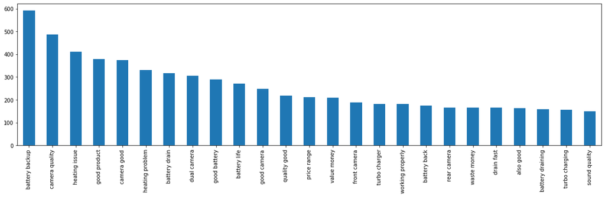

```python
DTM_bigram.sum().sort_values(ascending=False).head(25).plot.bar(figsize=(20,5))
```

### TFIDF for amazon reviews document

```python
from sklearn.feature_extraction.text import TfidfVectorizer

tfidf_vect = TfidfVectorizer(ngram_range=(2,2),max_features= 200)
```

```python
X = tfidf_vect.fit_transform(reviews['clean_review'])
X
```

```
<14675x200 sparse matrix of type '<class 'numpy.float64'>'
	with 16995 stored elements in Compressed Sparse Row format>
```

```python
print(tfidf_vect.get_feature_names())
```

```
['4000 mah', '4000mah battery', '4gb ram', 'also good', 'awesome product', 'back camera', 'back cover', 'backup good', 'bad battery', 'bad camera', 'bad experience', 'bad product', 'battery also', 'battery back', 'battery backup', 'battery charging', 'battery drain', 'battery draining', 'battery goo…
```

```python
tfidf = pd.DataFrame(X.toarray(),columns = tfidf_vect.get_feature_names())
tfidf
```

|  | 4000 mah | 4000mah battery | 4gb ram | also good | awesome product | back camera | back cover | backup good | bad battery | bad camera | bad experience | bad product | battery also | battery back | battery backup | battery charging | battery drain | battery draining | battery good | battery issue | battery last | battery life | battery performance | battery problem | best price | best product | bokeh effect | build quality | buy product | … |
| --- | --- | --- | --- | --- | --- | --- | --- | --- | --- | --- | --- | --- | --- | --- | --- | --- | --- | --- | --- | --- | --- | --- | --- | --- | --- | --- | --- | --- | --- | --- |
| 0 | 0.0 | 0.0 | 0.0 | 0.0 | 0.0 | 0.0 | 0.000000 | 0.0 | 0.0 | 0.0 | 0.0 | 0.0 | 0.0 | 0.0 | 0.0 | 0.0 | 0.0 | 0.000000 | 0.0 | 0.0 | 0.0 | 0.0 | 0.0 | 0.0 | 0.0 | 0.0 | 0.0 | 0.0 | 0.0 | … |
| 1 | 0.0 | 0.0 | 0.0 | 0.0 | 0.0 | 0.0 | 0.000000 | 0.0 | 0.0 | 0.0 | 0.0 | 0.0 | 0.0 | 0.0 | 0.0 | 0.0 | 0.0 | 0.625036 | 0.0 | 0.0 | 0.0 | 0.0 | 0.0 | 0.0 | 0.0 | 0.0 | 0.0 | 0.0 | 0.0 | … |
| 2 | 0.0 | 0.0 | 0.0 | 0.0 | 0.0 | 0.0 | 0.000000 | 0.0 | 0.0 | 0.0 | 0.0 | 0.0 | 0.0 | 0.0 | 0.0 | 0.0 | 0.0 | 0.000000 | 0.0 | 0.0 | 0.0 | 0.0 | 0.0 | 0.0 | 0.0 | 0.0 | 0.0 | 0.0 | 0.0 | … |
| 3 | 0.0 | 0.0 | 0.0 | 0.0 | 0.0 | 0.0 | 0.000000 | 0.0 | 0.0 | 0.0 | 0.0 | 0.0 | 0.0 | 0.0 | 0.0 | 0.0 | 0.0 | 0.000000 | 0.0 | 0.0 | 0.0 | 0.0 | 0.0 | 0.0 | 0.0 | 0.0 | 0.0 | 0.0 | 0.0 | … |
| 4 | 0.0 | 0.0 | 0.0 | 0.0 | 0.0 | 0.0 | 0.000000 | 0.0 | 0.0 | 0.0 | 0.0 | 0.0 | 0.0 | 0.0 | 0.0 | 0.0 | 0.0 | 0.000000 | 0.0 | 0.0 | 0.0 | 0.0 | 0.0 | 0.0 | 0.0 | 0.0 | 0.0 | 0.0 | 0.0 | … |
| ... | ... | ... | ... | ... | ... | ... | ... | ... | ... | ... | ... | ... | ... | ... | ... | ... | ... | ... | ... | ... | ... | ... | ... | ... | ... | ... | ... | ... | ... | … |
| 14670 | 0.0 | 0.0 | 0.0 | 0.0 | 0.0 | 0.0 | 0.000000 | 0.0 | 0.0 | 0.0 | 0.0 | 0.0 | 0.0 | 0.0 | 0.0 | 0.0 | 0.0 | 0.000000 | 0.0 | 0.0 | 0.0 | 0.0 | 0.0 | 0.0 | 0.0 | 0.0 | 0.0 | 0.0 | 0.0 | … |
| 14671 | 0.0 | 0.0 | 0.0 | 0.0 | 0.0 | 0.0 | 0.807329 | 0.0 | 0.0 | 0.0 | 0.0 | 0.0 | 0.0 | 0.0 | 0.0 | 0.0 | 0.0 | 0.000000 | 0.0 | 0.0 | 0.0 | 0.0 | 0.0 | 0.0 | 0.0 | 0.0 | 0.0 | 0.0 | 0.0 | … |
| 14672 | 0.0 | 0.0 | 0.0 | 0.0 | 0.0 | 0.0 | 0.000000 | 0.0 | 0.0 | 0.0 | 0.0 | 0.0 | 0.0 | 0.0 | 0.0 | 0.0 | 0.0 | 0.000000 | 0.0 | 0.0 | 0.0 | 0.0 | 0.0 | 0.0 | 0.0 | 0.0 | 0.0 | 0.0 | 0.0 | … |
| 14673 | 0.0 | 0.0 | 0.0 | 0.0 | 0.0 | 0.0 | 0.000000 | 0.0 | 0.0 | 0.0 | 0.0 | 0.0 | 0.0 | 0.0 | 0.0 | 0.0 | 0.0 | 0.000000 | 0.0 | 0.0 | 0.0 | 0.0 | 0.0 | 0.0 | 0.0 | 0.0 | 0.0 | 0.0 | 0.0 | … |
| 14674 | 0.0 | 0.0 | 0.0 | 0.0 | 0.0 | 0.0 | 0.000000 | 0.0 | 0.0 | 0.0 | 0.0 | 0.0 | 0.0 | 0.0 | 0.0 | 0.0 | 0.0 | 0.000000 | 0.0 | 0.0 | 0.0 | 0.0 | 0.0 | 0.0 | 0.0 | 0.0 | 0.0 | 0.0 | 0.0 | … |

14675 rows × 200 columns

```python
top_5 = tfidf.loc[(tfidf['battery drain']!=0.0) & (tfidf['camera good']!=0.0)].sort_values(by=['battery drain'], ascending = False)
```

```python
batteri_drain = top_5[['battery drain']].sort_values(by =['battery drain'] , ascending = False)
```

```python
camera_good = top_5[['camera good']].sort_values(by =['camera good'] , ascending = False)
```

```python
batteri_drain.head()
```

|  | battery drain |
| --- | --- |
| 645 | 0.556629 |
| 11347 | 0.556629 |
| 1561 | 0.486442 |
| 5810 | 0.457884 |
| 5303 | 0.396543 |

```python
camera_good.head()
```

|  | camera good |
| --- | --- |
| 645 | 0.535543 |
| 11347 | 0.535543 |
| 1561 | 0.468015 |
| 5810 | 0.440539 |
| 5303 | 0.381521 |

```python
reviews['tfidf_battery drain'] = batteri_drain['battery drain']
```

- pd.set_option('display.max_columns', None)
- pd.set_option('display.max_colwidth', -1)

```python
top_5_reviews = reviews.sort_values(by= 'tfidf_battery drain',ascending=False).head().review
```

```python
for i in top_5_reviews.index:
    print(top_5_reviews[i])
```

```
Here are the cons of this phone1. Too heavy (180gms)2.Heats up while playing games3. Lags while gaming4. Rear camera isn't that good (whitish images)5. Volume buttons are made up of plastic6.Big bezels covers lot of space7. Battery drains faster
Cons:-1. Heating Issue2. Battery Drain Quickly3. Hotspot Issue4. Rear camera is not good
Not better phone... camera not good .... battery drain fast ... heating issueHow I can do this phone .( Return & Refund ) ?.
Overall product is gud in performance. Camera is good. Battery drains much, lasts one day on moderate use..slight heating on charge...remaining all process r excellent
Useless phone.1. It does not work properly when you are playing music via bluetooth. Sound cracks.2. Mirror casting is not available. You have to use chromecast.3. Overheating problem. Leads to battery drain.4. Dual camera in no good. Normal camera of a similarly priced phone works much better.5. Mo…
```

#### Post class assignment

```python
#   Using the below documents:
document1 = "Python is a 2000 made-for-TV horror movie directed by Richard Clabaugh. The film features several cult favorite actors, including William Zabka of The Karate Kid fame, Wil Wheaton, Casper Van Dien, Jenny McCarthy, Keith Coogan, Robert Englund (best known for his role as Freddy Krueger in the A Nightmare on Elm Street series of films), Dana Barron, David Bowe, and Sean Whalen. The film concerns a genetically engineered snake, a python, that escapes and unleashes itself on a small town. It includes the classic final girl scenario evident in films like Friday the 13th. It was filmed in Los Angeles,  California and Malibu, California. Python was followed by two sequels: Python  II (2002) and Boa vs. Python (2004), both also made-for-TV films."
document2 = "Python, from the Greek word (πύθων/πύθωνας), is a genus of nonvenomous pythons found in Africa and Asia. Currently, 7 species are recognised. A member of this genus, P. reticulatus, is among the longest snakes known."
document3 = "The Colt Python is a .357 Magnum caliber revolver formerly manufactured by Colt's Manufacturing Company of Hartford, Connecticut. It is sometimes referred to as a ""Combat Magnum"". It was first introduced in 1955, the same year as Smith &amp; Wesson's M29 .44 Magnum. The now discontinued Colt Python targeted the premium revolver market segment. Some firearm collectors and writers such as Jeff Cooper, Ian V. Hogg, Chuck Hawks, Leroy Thompson, Renee Smeets and Martin Dougherty have described the Python as the finest production revolver ever made."
```

Find the following: 1) Top 3 words unigram based on TF-IDF for document 3.

2) The difference between the TF-IDF weightage of word films and film in document 1.

Fill your answer below: a. 0.09639805522826536

3) Which is the document which is returned first when you search for the word "python", if there is a clash then document1 has more precedence than document 2 than document3

```python
from nltk.tokenize import word_tokenize
```

```python
from string import punctuation
from nltk.corpus import stopwords
```

```python
def clean_txt_1(sent):
    tokens = word_tokenize(sent.lower())
    stop_updated = stopwords.words("english") + list(punctuation)
    final_word = [term for term in tokens if term not in stop_updated
               and len(term) > 2]
    res = " ".join(final_word)
    return res
```

```python
Doc1 = clean_txt_1(document1)
Doc2 = clean_txt_1(document2)
Doc3 = clean_txt_1(document3)

data_zip = zip([Doc1,Doc2,Doc3])
```

```python
df = pd.DataFrame(data_zip)
df.columns = ['document']
```

```python
from sklearn.feature_extraction.text import TfidfVectorizer,TfidfTransformer
TV = TfidfVectorizer()
```

```python
Y = TV.fit_transform(df['document'])
Y
```

```
<3x144 sparse matrix of type '<class 'numpy.float64'>'
	with 148 stored elements in Compressed Sparse Row format>
```

```python
tfidf = pd.DataFrame(Y.toarray(),columns = TV.get_feature_names())
```

```python
tfidf_T = tfidf.T
```

```python
tfidf_T.columns = ['document1','document2','document3']
```

```python
tfidf_T['document2'].sort_values(ascending=False).head()
```

```
genus      0.427108
πύθωνας    0.213554
asia       0.213554
found      0.213554
πύθων      0.213554
Name: document2, dtype: float64
```

```python
tfidf_T['document3'].sort_values(ascending=False).head()
```

```
magnum      0.347064
revolver    0.347064
colt        0.347064
python      0.204981
finest      0.115688
Name: document3, dtype: float64
```

```python
tfidf_T['document1'].sort_values(ascending=False).head()
```

```
films         0.289194
python        0.284671
california    0.192796
tv            0.192796
film          0.192796
Name: document1, dtype: float64
```

```python
docc1 = tfidf_T['document1'].sort_values(ascending=False).head()
```

```python
docc1.films - docc1.film
```

```
0.09639805522826536
```

## Practice block

```python
doc_list = ['d{}'.format(i) for i in range(1,8)]
term_list = ['t{}'.format(i) for i in range(1,7)]
```

```python
term_list[0] = [2,1,0,0,0,0,0]
term_list[1] = [1,2,0,0,0,0,1]
term_list[2] = [3,1,0,0,1,1,0]
term_list[3] = [0,0,1,2,1,1,1]
term_list[4] = [0,0,1,1,1,1,1]
term_list[5] = [0,0,1,1,0,0,0]
```

```python
pp = pd.DataFrame(term_list, columns= doc_list)
```

```python
pp
```

|  | d1 | d2 | d3 | d4 | d5 | d6 | d7 |
| --- | --- | --- | --- | --- | --- | --- | --- |
| 0 | 2 | 1 | 0 | 0 | 0 | 0 | 0 |
| 1 | 1 | 2 | 0 | 0 | 0 | 0 | 1 |
| 2 | 3 | 1 | 0 | 0 | 1 | 1 | 0 |
| 3 | 0 | 0 | 1 | 2 | 1 | 1 | 1 |
| 4 | 0 | 0 | 1 | 1 | 1 | 1 | 1 |
| 5 | 0 | 0 | 1 | 1 | 0 | 0 | 0 |

```python
z = TV.fit_transform(pp)
```

```python
TFIDF = pd.DataFrame(z.todense(),columns = TV.get_feature_names())
```

```python
p = TfidfTransformer(smooth_idf=True,use_idf=True)
xx = p.fit(pp)
```

### Sentiment score analysis

```python
afinn =pd.read_csv(r'C:\Users\Administrator\Desktop\unstructured elective\dataset\AFINN-111.txt','\t',header=None)
term_scores = dict(afinn.values)
```

```python
def get_sentiment(text):
    score=0
    tokens = word_tokenize(text)
    for word in tokens:
        score  = score+term_scores.get(word,0)
    return score
```

```python
reviews.drop('tfidf_battery drain',axis=1,inplace=True)
```

```python
reviews['cacl_sentiment'] = reviews['clean_review'].apply(get_sentiment)
```

```python
reviews.sort_values(by='cacl_sentiment',ascending=False)
```

[output not shown]

```python
reviews['sent_prediction'] = reviews.cacl_sentiment.apply(lambda x :1 if x>2 else 0)
```

```python
reviews
```

[output not shown]

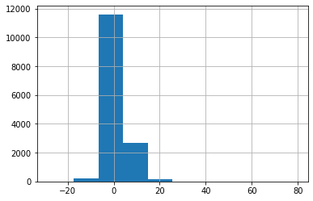

```python
reviews.cacl_sentiment.hist()
```

```python
from sklearn.metrics import accuracy_score,confusion_matrix
```

```python
acurracy = accuracy_score(reviews.sentiment,reviews.sent_prediction)*100
```

```python
acurracy
```

```
77.70357751277683
```

```python
from nltk.sentiment.vader import SentimentIntensityAnalyzer
```

```python
analyser = SentimentIntensityAnalyzer()
```

```python
def get_vader_sentiment(text):
    return analyser.polarity_scores(text)['compound']
```

```python
reviews['original_review_score'] = reviews['review'].apply(get_vader_sentiment)
```

```python
reviews['sent_prediction_original'] = reviews.original_review_score.apply(lambda x :1 if x>0.3 else 0)
reviews.head(1)
```

|  | sentiment | review | clean_review | cacl_sentiment | sent_prediction | original_review_score | sent_prediction_original |
| --- | --- | --- | --- | --- | --- | --- | --- |
| 0 | 1 | Good but need updates and improvements | good need update improvement | 5 | 1 | 0.5994 | 1 |

```python
acurracy_original = accuracy_score(reviews.sentiment,reviews.sent_prediction_original)*100
acurracy_original
```

```
79.90459965928449
```

### Sentiment prediction Strategy 3 : building our own model

- step 1 : get X and Y
- setp 2 : split into test and train
- step 3 : converting text to numbers (countvectorizer or TFIDFvectorizer)
- step 4 : train
- step 5 : test and get the accuracy scores

```python
x = reviews['clean_review'].values
y = reviews['sentiment'].values
```

```python
from sklearn.model_selection import train_test_split

x_train,x_test,y_train,y_test = train_test_split(x,y , test_size = 0.3 , random_state= 42)
```

```python
from sklearn.feature_extraction.text import CountVectorizer,TfidfVectorizer
```

```python
count_v = CountVectorizer()
```

- Extract the features on the review for train - fit
- Compute the count of every word extracted in every documnet(reviews)

```python
x_train_bow = count_v.fit_transform(x_train)
```

- For all the features extracted , compute the count in the test data set of reviews

```python
x_test_bow = count_v.transform(x_test)
```

```python
print(x_train_bow.shape,x_test_bow.shape)
```

```
(10272, 9488) (4403, 9488)
```

```python
from sklearn.naive_bayes import MultinomialNB
```

```python
GNB = MultinomialNB()
GNB.fit(x_train_bow.toarray(),y_train)
```

```
MultinomialNB(alpha=1.0, class_prior=None, fit_prior=True)
```

```python
y_pred = GNB.predict(x_test_bow)
```

```python
print(y_pred)
```

```
[0 0 0 ... 0 0 0]
```

```python
from sklearn.metrics import confusion_matrix,accuracy_score
con_matrix = confusion_matrix(y_test,y_pred)
print(con_matrix)
```

```
[[1953  358]
 [ 297 1795]]
```

```python
print(x_test_bow.shape,y_pred.shape)
```

```
(4403, 9488) (4403,)
```

```python
score = accuracy_score(y_test,y_pred)*100
```

```python
score
```

```
85.1237792414263
```

## Email_spam_classification_Case_study

```python
spam = pd.read_excel(r'C:\Users\Administrator\Desktop\unstructured elective\dataset\data.csv.xlsx')
spam
```

|  | email subject | Label ( Spam/not_Spam) |
| --- | --- | --- |
| 0 | Great offer ends today | spam |
| 1 | Your twitter Account is ready | Not spam |
| 2 | your account has won 100 cores | spam |
| 3 | Get expert opinion for your retirement. Offers ends today | spam |
| 4 | payment Acknowledgement | Not spam |
| 5 | Congratulations. Your coupon has won Ipad today | spam |

```python
stop_updated1 = stop_nltk + ["...",".."] +\
["mobile","phone","lenovo","k8","note","n't",'100','would','could']
```

```python
def clean_txt1(sent):
    tokens = word_tokenize(sent.lower())
    lemmed = [lemm.lemmatize(term) for term in tokens \
               if term not in stop_updated1 and \
                term not in list(punctuation) and\
               len(term) > 2]
    res = " ".join(lemmed)
    return res
```

```python
spam.columns = [i.lower() for i in spam.columns]
```

```python
spam['clean_email_subject'] = spam['email subject'].apply(clean_txt1)
cc = count_v.fit_transform(spam['clean_email_subject'])
DTM_original = pd.DataFrame(cc.toarray() , columns = count_v.get_feature_names())
DTM_original.sum().sort_values(ascending=False)
```

```
today              3
account            2
offer              2
end                2
expert             1
acknowledgement    1
congratulation     1
core               1
coupon             1
twitter            1
get                1
ipad               1
opinion            1
payment            1
ready              1
retirement         1
great              1
dtype: int64
```

```python
DTM_original['label'] = spam['label ( spam/not_spam)']
DTM_original
```

|  | account | acknowledgement | congratulation | core | coupon | end | expert | get | great | ipad | offer | opinion | payment | ready | retirement | today | twitter | label |
| --- | --- | --- | --- | --- | --- | --- | --- | --- | --- | --- | --- | --- | --- | --- | --- | --- | --- | --- |
| 0 | 0 | 0 | 0 | 0 | 0 | 1 | 0 | 0 | 1 | 0 | 1 | 0 | 0 | 0 | 0 | 1 | 0 | spam |
| 1 | 1 | 0 | 0 | 0 | 0 | 0 | 0 | 0 | 0 | 0 | 0 | 0 | 0 | 1 | 0 | 0 | 1 | Not spam |
| 2 | 1 | 0 | 0 | 1 | 0 | 0 | 0 | 0 | 0 | 0 | 0 | 0 | 0 | 0 | 0 | 0 | 0 | spam |
| 3 | 0 | 0 | 0 | 0 | 0 | 1 | 1 | 1 | 0 | 0 | 1 | 1 | 0 | 0 | 1 | 1 | 0 | spam |
| 4 | 0 | 1 | 0 | 0 | 0 | 0 | 0 | 0 | 0 | 0 | 0 | 0 | 1 | 0 | 0 | 0 | 0 | Not spam |
| 5 | 0 | 0 | 1 | 0 | 1 | 0 | 0 | 0 | 0 | 1 | 0 | 0 | 0 | 0 | 0 | 1 | 0 | spam |

```python
X = spam['clean_email_subject'].iloc[0:6].values
Y = spam['label ( spam/not_spam)'].iloc[0:6].apply(lambda x : 1 if x =='spam' else 0)
```

```python
X_train,X_test,Y_train,Y_test= train_test_split(X,Y, test_size =0.2,random_state =42)
```

```python
from sklearn.feature_extraction.text import TfidfVectorizer

tf = TfidfVectorizer()
```

```python
X_train_words= tf.fit_transform(X_train)
```

```python
X_test_words = tf.transform(X_test)
```

```python
print(X_train_words.shape,X_test_words.shape )
```

```
(4, 14) (2, 14)
```

```python
dtm = pd.DataFrame(X_train_words.toarray(),columns = tf.get_feature_names())
dtm
```

|  | account | acknowledgement | congratulation | core | coupon | end | expert | get | ipad | offer | opinion | payment | retirement | today |
| --- | --- | --- | --- | --- | --- | --- | --- | --- | --- | --- | --- | --- | --- | --- |
| 0 | 0.000000 | 0.000000 | 0.525473 | 0.000000 | 0.525473 | 0.000000 | 0.000000 | 0.000000 | 0.525473 | 0.000000 | 0.000000 | 0.000000 | 0.000000 | 0.414289 |
| 1 | 0.707107 | 0.000000 | 0.000000 | 0.707107 | 0.000000 | 0.000000 | 0.000000 | 0.000000 | 0.000000 | 0.000000 | 0.000000 | 0.000000 | 0.000000 | 0.000000 |
| 2 | 0.000000 | 0.707107 | 0.000000 | 0.000000 | 0.000000 | 0.000000 | 0.000000 | 0.000000 | 0.000000 | 0.000000 | 0.000000 | 0.707107 | 0.000000 | 0.000000 |
| 3 | 0.000000 | 0.000000 | 0.000000 | 0.000000 | 0.000000 | 0.388614 | 0.388614 | 0.388614 | 0.000000 | 0.388614 | 0.388614 | 0.000000 | 0.388614 | 0.306388 |

```python
from sklearn.naive_bayes import MultinomialNB
MNB = MultinomialNB()
MNB.fit(X_train_words,Y_train)
```

```
MultinomialNB(alpha=1.0, class_prior=None, fit_prior=True)
```

```python
a_score = accuracy_score(Y_test,MNB.predict(X_test_words))*100
```

```python
a_score
```

```
50.0
```